# Titanic (Machine Learning from Disaster)

### Predict survival on the Titanic

### 1) Import libraries

```python
import pandas as pd
import matplotlib.pyplot as plt
import seaborn as sns
import numpy as np
```

### 2) Read dataset

```python
train = pd.read_csv('train.csv')
test = pd.read_csv('test.csv')
```

```python
print('Train shape: ', train.shape)
print('Test shape: ', test.shape)
```

```
Train shape:  (891, 12)
Test shape:  (418, 11)
```

```python
train.dtypes
```

```
PassengerId      int64
Survived         int64
Pclass           int64
Name            object
Sex             object
Age            float64
SibSp            int64
Parch            int64
Ticket          object
Fare           float64
Cabin           object
Embarked        object
dtype: object
```

```python
test.dtypes
```

```
PassengerId      int64
Pclass           int64
Name            object
Sex             object
Age            float64
SibSp            int64
Parch            int64
Ticket          object
Fare           float64
Cabin           object
Embarked        object
dtype: object
```

```python
train.head()
```

|  | PassengerId | Survived | Pclass | Name | Sex | Age | SibSp | Parch | Ticket | Fare | Cabin | Embarked |
| --- | --- | --- | --- | --- | --- | --- | --- | --- | --- | --- | --- | --- |
| 0 | 1 | 0 | 3 | Braund, Mr. Owen Harris | male | 22.0 | 1 | 0 | A/5 21171 | 7.2500 | NaN | S |
| 1 | 2 | 1 | 1 | Cumings, Mrs. John Bradley (Florence Briggs Th... | female | 38.0 | 1 | 0 | PC 17599 | 71.2833 | C85 | C |
| 2 | 3 | 1 | 3 | Heikkinen, Miss. Laina | female | 26.0 | 0 | 0 | STON/O2. 3101282 | 7.9250 | NaN | S |
| 3 | 4 | 1 | 1 | Futrelle, Mrs. Jacques Heath (Lily May Peel) | female | 35.0 | 1 | 0 | 113803 | 53.1000 | C123 | S |
| 4 | 5 | 0 | 3 | Allen, Mr. William Henry | male | 35.0 | 0 | 0 | 373450 | 8.0500 | NaN | S |

### Data Dictionary

- Survived: 0 = No, 1 = Yes
- pclass: Ticket class 1 = 1st, 2 = 2nd, 3 = 3rd
- sibsp: # of siblings / spouses aboard the Titanic
- parch: # of parents / children aboard the Titanic
- ticket: Ticket number
- cabin: Cabin number
- embarked: Port of Embarkation C = Cherbourg, Q = Queenstown, S = Southampton

### 3) Explore and clean the data

```
train.shape:  (891, 12)
```

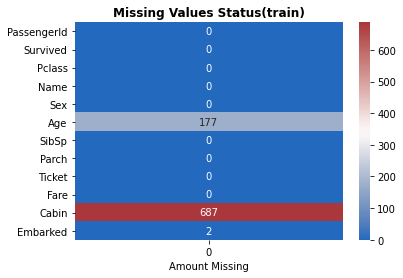

```
There're 77% NaN in Cabin's
```

```python
plt.title('Missing Values Status(train)', fontweight='bold')
ax = sns.heatmap(train.isna().sum().to_frame(), annot=True, fmt='d', cmap='vlag')
ax.set_xlabel('Amount Missing')
print("train.shape: ", train.shape)
plt.show()
print("There're 77% NaN in Cabin's")
```

```
test.shape:  (418, 11)
```

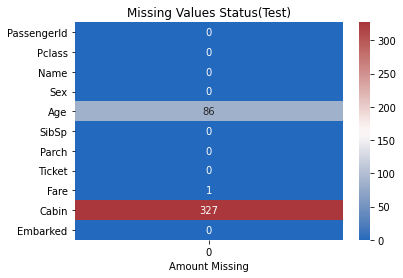

```
There're 78% NaN in Cabin's
```

```python
plt.title('Missing Values Status(Test)')
ax = sns.heatmap(test.isna().sum().to_frame(), annot=True, fmt='d', cmap='vlag')
ax.set_xlabel('Amount Missing')
print("test.shape: ", test.shape)
plt.show()
print("There're 78% NaN in Cabin's")
```

```python
# I'm gonna drop the column, because I don't know yet how to do the wragling column which has more than 50% missing values
train.drop('Cabin', axis=1, inplace=True)
test.drop('Cabin', axis=1, inplace=True)
```

##### Explore

```python
def bar_chart(feature):
    survived = train[train['Survived']==1][feature].value_counts()
    dead = train[train['Survived']==0][feature].value_counts()
    df = pd.DataFrame([survived,dead])
    df.index=['Survived','Dead']
    df.plot(kind='bar',stacked=True,figsize=(10,5))
```

|  | Pclass | Survived |
| --- | --- | --- |
| 0 | 1 | 0.629630 |
| 1 | 2 | 0.472826 |
| 2 | 3 | 0.242363 |

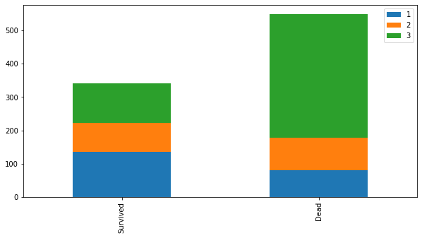

```python
bar_chart('Pclass')
train[['Pclass','Survived']].groupby(['Pclass'], as_index=False).mean().sort_values(by=['Survived'], ascending=False)
```

- Passengers in 1st class(Pclass=1) mostly survived (with 62.9% survived)
- Passengers in 3rd class(Pclass=3) have a serious effect to survived with only 24.2% survived

So, it is important to consider when choosing a class **consider Pclass for model training**

|  | Sex | Survived |
| --- | --- | --- |
| 0 | female | 0.742038 |
| 1 | male | 0.188908 |

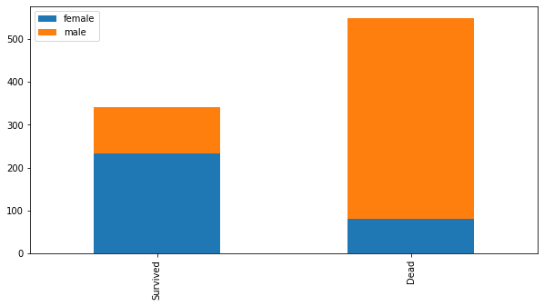

```python
bar_chart('Sex')
train[['Sex','Survived']].groupby(['Sex'], as_index=False).mean().sort_values(by=['Survived'], ascending=False)
```

Female passengers had much better survival rate than males

Gender has effect for the survival rate **consider Sex for model training**

|  | SibSp | Survived |
| --- | --- | --- |
| 1 | 1 | 0.535885 |
| 2 | 2 | 0.464286 |
| 0 | 0 | 0.345395 |
| 3 | 3 | 0.250000 |
| 4 | 4 | 0.166667 |
| 5 | 5 | 0.000000 |
| 6 | 8 | 0.000000 |

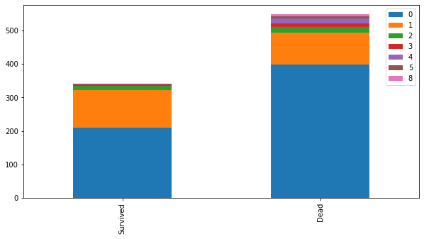

```python
bar_chart('SibSp')
train[['SibSp','Survived']].groupby(['SibSp'], as_index=False).mean().sort_values(by=['Survived'], ascending=False)
```

a person who boarded without sibling, more likely **Dead**

|  | Parch | Survived |
| --- | --- | --- |
| 3 | 3 | 0.600000 |
| 1 | 1 | 0.550847 |
| 2 | 2 | 0.500000 |
| 0 | 0 | 0.343658 |
| 5 | 5 | 0.200000 |
| 4 | 4 | 0.000000 |
| 6 | 6 | 0.000000 |

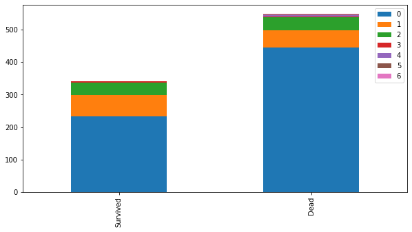

```python
bar_chart('Parch')
train[['Parch','Survived']].groupby(['Parch'], as_index=False).mean().sort_values(by=['Survived'], ascending=False)
```

a person who boarded with more than 1 and less than 4 is more likely **Survived**

### 4) Feature Engineering

using domain knowledge of the data to create features (feature vectors) that make machine learning algorithms work.

```python
train_test = [train,test]

for dataset in train_test:
    dataset['Title'] = dataset['Name'].str.extract(' ([A-Za-z]+)\.', expand=False)
```

```python
train['Title'].value_counts()
```

```
Mr          517
Miss        182
Mrs         125
Master       40
Dr            7
Rev           6
Col           2
Major         2
Mlle          2
Sir           1
Ms            1
Jonkheer      1
Lady          1
Don           1
Mme           1
Countess      1
Capt          1
Name: Title, dtype: int64
```

```python
test['Title'].value_counts()
```

```
Mr        240
Miss       78
Mrs        72
Master     21
Rev         2
Col         2
Dr          1
Ms          1
Dona        1
Name: Title, dtype: int64
```

```python
title_mapping = {"Mr": 0, "Miss": 1, "Mrs": 2,
                 "Master": 3, "Dr": 3, "Rev": 3, "Col": 3, "Major": 3, "Mlle": 3,"Countess": 3,
                 "Ms": 3, "Lady": 3, "Jonkheer": 3, "Don": 3, "Dona" : 3, "Mme": 3,"Capt": 3,"Sir": 3 }
for dataset in train_test:
    dataset['Title'] = dataset['Title'].map(title_mapping)
```

```python
test.head()
```

|  | PassengerId | Pclass | Name | Sex | Age | SibSp | Parch | Ticket | Fare | Embarked | Title |
| --- | --- | --- | --- | --- | --- | --- | --- | --- | --- | --- | --- |
| 0 | 892 | 3 | Kelly, Mr. James | male | 34.5 | 0 | 0 | 330911 | 7.8292 | Q | 0 |
| 1 | 893 | 3 | Wilkes, Mrs. James (Ellen Needs) | female | 47.0 | 1 | 0 | 363272 | 7.0000 | S | 2 |
| 2 | 894 | 2 | Myles, Mr. Thomas Francis | male | 62.0 | 0 | 0 | 240276 | 9.6875 | Q | 0 |
| 3 | 895 | 3 | Wirz, Mr. Albert | male | 27.0 | 0 | 0 | 315154 | 8.6625 | S | 0 |
| 4 | 896 | 3 | Hirvonen, Mrs. Alexander (Helga E Lindqvist) | female | 22.0 | 1 | 1 | 3101298 | 12.2875 | S | 2 |

```python
train.drop('Name', axis=1, inplace=True)
test.drop('Name', axis=1, inplace=True)
```

| Title | Survived |
| --- | --- |
| 2 | 0.792000 |
| 1 | 0.697802 |
| 3 | 0.522388 |
| 0 | 0.156673 |

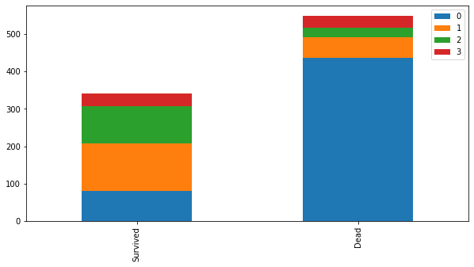

```python
bar_chart('Title')
train[['Title','Survived']].groupby('Title').mean().sort_values(by=['Survived'], ascending=False)
```

a person who is **Mrs** is more likely survived with 79.2% possibility

```python
for dataset in train_test:
    dataset['Sex'] = dataset['Sex'].map({'female':0,'male':1}).astype(int)
```

```python
train.head()
```

|  | PassengerId | Survived | Pclass | Sex | Age | SibSp | Parch | Ticket | Fare | Embarked | Title |
| --- | --- | --- | --- | --- | --- | --- | --- | --- | --- | --- | --- |
| 0 | 1 | 0 | 3 | 1 | 22.0 | 1 | 0 | A/5 21171 | 7.2500 | S | 0 |
| 1 | 2 | 1 | 1 | 0 | 38.0 | 1 | 0 | PC 17599 | 71.2833 | C | 2 |
| 2 | 3 | 1 | 3 | 0 | 26.0 | 0 | 0 | STON/O2. 3101282 | 7.9250 | S | 1 |
| 3 | 4 | 1 | 1 | 0 | 35.0 | 1 | 0 | 113803 | 53.1000 | S | 2 |
| 4 | 5 | 0 | 3 | 1 | 35.0 | 0 | 0 | 373450 | 8.0500 | S | 0 |

```python
train['Age'].fillna(train.groupby('Title')['Age'].transform('median'), inplace=True)
test['Age'].fillna(train.groupby('Title')['Age'].transform('median'),inplace=True)
```

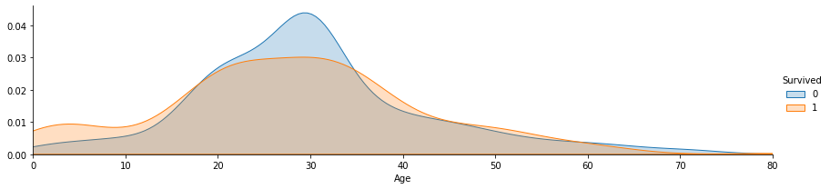

```python
facet = sns.FacetGrid(train, hue="Survived",aspect=4)
facet.map(sns.kdeplot,'Age',shade= True)
facet.set(xlim=(0, train['Age'].max()))
facet.add_legend()

plt.show()
```

```python
for dataset in train_test:
    dataset.loc[ dataset['Age'] <= 20, 'Age'] = 0
    dataset.loc[(dataset['Age'] > 20) & (dataset['Age'] <= 40), 'Age'] = 1
    dataset.loc[(dataset['Age'] > 40) & (dataset['Age'] <= 50), 'Age'] = 2
    dataset.loc[(dataset['Age'] > 50) & (dataset['Age'] <= 64), 'Age'] = 3
    dataset.loc[(dataset['Age'] > 64) & (dataset['Age'] <= 80), 'Age'] = 4
    dataset.loc[ dataset['Age'] > 80, 'Age']
train.head()
```

|  | PassengerId | Survived | Pclass | Sex | Age | SibSp | Parch | Ticket | Fare | Embarked | Title |
| --- | --- | --- | --- | --- | --- | --- | --- | --- | --- | --- | --- |
| 0 | 1 | 0 | 3 | 1 | 1.0 | 1 | 0 | A/5 21171 | 7.2500 | S | 0 |
| 1 | 2 | 1 | 1 | 0 | 1.0 | 1 | 0 | PC 17599 | 71.2833 | C | 2 |
| 2 | 3 | 1 | 3 | 0 | 1.0 | 0 | 0 | STON/O2. 3101282 | 7.9250 | S | 1 |
| 3 | 4 | 1 | 1 | 0 | 1.0 | 1 | 0 | 113803 | 53.1000 | S | 2 |
| 4 | 5 | 0 | 3 | 1 | 1.0 | 0 | 0 | 373450 | 8.0500 | S | 0 |

```python
train.Age.unique()
```

```
array([1., 3., 0., 4., 2.])
```

| Age | Survived |
| --- | --- |
| 0.0 | 0.456522 |
| 3.0 | 0.396226 |
| 2.0 | 0.383721 |
| 1.0 | 0.364452 |
| 4.0 | 0.090909 |

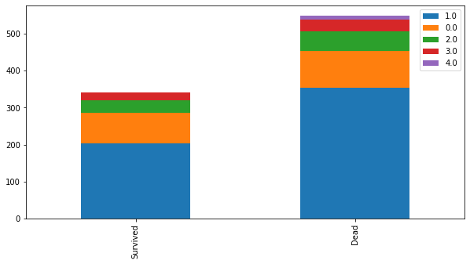

```python
bar_chart('Age')
train[['Age','Survived']].groupby('Age').mean().sort_values(by=['Survived'], ascending=False)
```

```python
train["Fare"].fillna(train.groupby("Pclass")["Fare"].transform("median"), inplace=True)
test["Fare"].fillna(test.groupby("Pclass")["Fare"].transform("median"), inplace=True)
```

```python
train.head()
```

|  | PassengerId | Survived | Pclass | Sex | Age | SibSp | Parch | Ticket | Fare | Embarked | Title |
| --- | --- | --- | --- | --- | --- | --- | --- | --- | --- | --- | --- |
| 0 | 1 | 0 | 3 | 1 | 1.0 | 1 | 0 | A/5 21171 | 7.2500 | S | 0 |
| 1 | 2 | 1 | 1 | 0 | 1.0 | 1 | 0 | PC 17599 | 71.2833 | C | 2 |
| 2 | 3 | 1 | 3 | 0 | 1.0 | 0 | 0 | STON/O2. 3101282 | 7.9250 | S | 1 |
| 3 | 4 | 1 | 1 | 0 | 1.0 | 1 | 0 | 113803 | 53.1000 | S | 2 |
| 4 | 5 | 0 | 3 | 1 | 1.0 | 0 | 0 | 373450 | 8.0500 | S | 0 |

```python
train['Embarked'].replace(np.nan, 'S', inplace=True)
```

```python
embarked_mapping = {'S':0,'C':1,'Q':2}

for dataset in train_test:
    dataset['Embarked'] = dataset['Embarked'].map(embarked_mapping)
```

```python
train.head()
```

|  | PassengerId | Survived | Pclass | Sex | Age | SibSp | Parch | Ticket | Fare | Embarked | Title |
| --- | --- | --- | --- | --- | --- | --- | --- | --- | --- | --- | --- |
| 0 | 1 | 0 | 3 | 1 | 1.0 | 1 | 0 | A/5 21171 | 7.2500 | 0 | 0 |
| 1 | 2 | 1 | 1 | 0 | 1.0 | 1 | 0 | PC 17599 | 71.2833 | 1 | 2 |
| 2 | 3 | 1 | 3 | 0 | 1.0 | 0 | 0 | STON/O2. 3101282 | 7.9250 | 0 | 1 |
| 3 | 4 | 1 | 1 | 0 | 1.0 | 1 | 0 | 113803 | 53.1000 | 0 | 2 |
| 4 | 5 | 0 | 3 | 1 | 1.0 | 0 | 0 | 373450 | 8.0500 | 0 | 0 |

```python
test.head()
```

|  | PassengerId | Pclass | Sex | Age | SibSp | Parch | Ticket | Fare | Embarked | Title |
| --- | --- | --- | --- | --- | --- | --- | --- | --- | --- | --- |
| 0 | 892 | 3 | 1 | 1.0 | 0 | 0 | 330911 | 7.8292 | 2 | 0 |
| 1 | 893 | 3 | 0 | 2.0 | 1 | 0 | 363272 | 7.0000 | 0 | 2 |
| 2 | 894 | 2 | 1 | 3.0 | 0 | 0 | 240276 | 9.6875 | 2 | 0 |
| 3 | 895 | 3 | 1 | 1.0 | 0 | 0 | 315154 | 8.6625 | 0 | 0 |
| 4 | 896 | 3 | 0 | 1.0 | 1 | 1 | 3101298 | 12.2875 | 0 | 2 |

```python
for dataset in train_test:
    dataset.loc[ dataset['Fare'] <= 17, 'Fare'] = 0
    dataset.loc[(dataset['Fare'] > 17) & (dataset['Fare'] <= 30), 'Fare'] = 1
    dataset.loc[(dataset['Fare'] > 30) & (dataset['Fare'] <= 100), 'Fare'] = 2
    dataset.loc[(dataset['Fare'] > 100) & (dataset['Fare'] <= 600), 'Fare'] = 3
    dataset.loc[ dataset['Fare'] > 500, 'Fare']
train.head()
```

|  | PassengerId | Survived | Pclass | Sex | Age | SibSp | Parch | Ticket | Fare | Embarked | Title |
| --- | --- | --- | --- | --- | --- | --- | --- | --- | --- | --- | --- |
| 0 | 1 | 0 | 3 | 1 | 1.0 | 1 | 0 | A/5 21171 | 0.0 | 0 | 0 |
| 1 | 2 | 1 | 1 | 0 | 1.0 | 1 | 0 | PC 17599 | 2.0 | 1 | 2 |
| 2 | 3 | 1 | 3 | 0 | 1.0 | 0 | 0 | STON/O2. 3101282 | 0.0 | 0 | 1 |
| 3 | 4 | 1 | 1 | 0 | 1.0 | 1 | 0 | 113803 | 2.0 | 0 | 2 |
| 4 | 5 | 0 | 3 | 1 | 1.0 | 0 | 0 | 373450 | 0.0 | 0 | 0 |

```python
train.Fare.unique()
```

```
array([0., 2., 1., 3.])
```

```python
train.drop(['Ticket','PassengerId'], axis=1, inplace=True)
test.drop('Ticket', axis=1, inplace=True)
```

```python
test.head()
```

|  | PassengerId | Pclass | Sex | Age | SibSp | Parch | Fare | Embarked | Title |
| --- | --- | --- | --- | --- | --- | --- | --- | --- | --- |
| 0 | 892 | 3 | 1 | 1.0 | 0 | 0 | 0.0 | 2 | 0 |
| 1 | 893 | 3 | 0 | 2.0 | 1 | 0 | 0.0 | 0 | 2 |
| 2 | 894 | 2 | 1 | 3.0 | 0 | 0 | 0.0 | 2 | 0 |
| 3 | 895 | 3 | 1 | 1.0 | 0 | 0 | 0.0 | 0 | 0 |
| 4 | 896 | 3 | 0 | 1.0 | 1 | 1 | 0.0 | 0 | 2 |

### 5) Modeling

```python
X_train = train.drop('Survived', axis=1)
Y_train = train['Survived']
X_test = test.drop('PassengerId', axis=1).copy()

X_train.shape, Y_train.shape, X_test.shape
```

```
((891, 8), (891,), (418, 8))
```

```python
from sklearn.neighbors import KNeighborsClassifier
from sklearn.tree import DecisionTreeClassifier
from sklearn.ensemble import RandomForestClassifier
from sklearn.naive_bayes import GaussianNB
from sklearn.svm import SVC
```

```python
decision_tree = DecisionTreeClassifier()
decision_tree.fit(X_train, Y_train)
Y_pred = decision_tree.predict(X_test)
acc_decision_tree = round(decision_tree.score(X_train, Y_train) * 100, 2)
acc_decision_tree
```

```
88.22
```

```python
random_forest = RandomForestClassifier(n_estimators=100)
random_forest.fit(X_train, Y_train)
Y_pred = random_forest.predict(X_test)
random_forest.score(X_train, Y_train)
acc_random_forest = round(random_forest.score(X_train, Y_train) * 100, 2)
acc_random_forest
```

```
88.1
```

```python
clf = SVC()
clf.fit(X_train, Y_train)
Y_pred = clf.predict(X_test)
clf.score(X_train, Y_train)
acc = round(clf.score(X_train, Y_train) *100, 2)
```

```python
acc
```

```
83.5
```

```python
c_knn = KNeighborsClassifier(n_neighbors = 1)
c_knn.fit(X_train, Y_train)
Y_pred = c_knn.predict(X_test)
c_knn.score(X_train, Y_train)
knn_o = round(c_knn.score(X_train, Y_train) *100,2)
knn_o
```

```
84.51
```

```python
nb = GaussianNB()
nb.fit(X_train, Y_train)
Y_pred = nb.predict(X_test)
nb.score(X_train, Y_train)
nb_o = round(nb.score(X_train, Y_train) * 100,2)
nb_o
```

```
80.58
```

```python
models = pd.DataFrame({
    'Model':['Decision Tree','Random Forest','SVC',
            'KNN','NB'],
    'Score':[acc_decision_tree,acc_random_forest,acc,knn_o,nb_o]})
models.sort_values(by='Score', ascending=False)
```

|  | Model | Score |
| --- | --- | --- |
| 0 | Decision Tree | 88.22 |
| 1 | Random Forest | 88.10 |
| 3 | KNN | 84.51 |
| 2 | SVC | 83.50 |
| 4 | NB | 80.58 |

### 6) Predict Test Dataset

```python
submission = pd.DataFrame({
        "PassengerId": test["PassengerId"],
        "Survived": Y_pred
    })
```

```python
#submission.to_csv('output.csv', index=False)
```

```python
submission
```

|  | PassengerId | Survived |
| --- | --- | --- |
| 0 | 892 | 0 |
| 1 | 893 | 1 |
| 2 | 894 | 0 |
| 3 | 895 | 0 |
| 4 | 896 | 1 |
| ... | ... | ... |
| 413 | 1305 | 0 |
| 414 | 1306 | 1 |
| 415 | 1307 | 0 |
| 416 | 1308 | 0 |
| 417 | 1309 | 1 |

418 rows × 2 columns

1 = **Survived** 0 = **Dead**